# Content

1. #### Load and Check Data
2. #### Variable Description
   1. Univariate Variable Analysis
      1. Categorical Variable
      2. Numerical Variable
3. #### Basic Data Analysis
4. #### Outlier Detection
5. #### Missing Value
   1. Find Missing Value
   2. Fill Missing Value
6. #### Visualization
   1. Correlation Between Sibsp -- Parch -- Age -- Fare -- Survived
   2. SibSp -- Survived
   3. Parch -- Survived
   4. Pclass -- Survived
   5. Age -- Survived
   6. Pclass -- Survived -- Age
   7. Embarked -- Sex -- Pclass -- Survived
   8. Embarked -- Sex -- Fare -- Survived
   9. Fill Missing: Age Feature
7. #### Feature Engineering
   1. Name to title
   2. SipSb,Parch to Family Size
   3. Embarked
   4. Ticket
   5. Pclass
   6. Sex
   7. Drop Passenger ID and Cabin
8. #### Modeling
   1. Train - Test Split
   2. Simple Logistic Regression
   3. Hyperparameter Tuning -- Grid Search -- Cross Validation
   4. Ensemble Modeling
   5. Prediction and Submission

```python
#Libraries
import pandas as pd

import numpy as np

import matplotlib.pyplot as plt
plt.style.use("bmh")
from collections import Counter

import seaborn as sns

import warnings
warnings.filterwarnings("ignore")
```

# 1) Load and Check Data

```python
train_df=pd.read_csv("train.csv")
test_df=pd.read_csv("test.csv")
test_PassengerId = test_df["PassengerId"]
```

```python
train_df.columns
```

```
Index(['PassengerId', 'Survived', 'Pclass', 'Name', 'Sex', 'Age', 'SibSp',
       'Parch', 'Ticket', 'Fare', 'Cabin', 'Embarked'],
      dtype='object')
```

```python
train_df.head()
```

|  | PassengerId | Survived | Pclass | Name | Sex | Age | SibSp | Parch | Ticket | Fare | Cabin | Embarked |
| --- | --- | --- | --- | --- | --- | --- | --- | --- | --- | --- | --- | --- |
| 0 | 1 | 0 | 3 | Braund, Mr. Owen Harris | male | 22.0 | 1 | 0 | A/5 21171 | 7.2500 | NaN | S |
| 1 | 2 | 1 | 1 | Cumings, Mrs. John Bradley (Florence Briggs Th... | female | 38.0 | 1 | 0 | PC 17599 | 71.2833 | C85 | C |
| 2 | 3 | 1 | 3 | Heikkinen, Miss. Laina | female | 26.0 | 0 | 0 | STON/O2. 3101282 | 7.9250 | NaN | S |
| 3 | 4 | 1 | 1 | Futrelle, Mrs. Jacques Heath (Lily May Peel) | female | 35.0 | 1 | 0 | 113803 | 53.1000 | C123 | S |
| 4 | 5 | 0 | 3 | Allen, Mr. William Henry | male | 35.0 | 0 | 0 | 373450 | 8.0500 | NaN | S |

```python
train_df.describe()
```

|  | PassengerId | Survived | Pclass | Age | SibSp | Parch | Fare |
| --- | --- | --- | --- | --- | --- | --- | --- |
| count | 891.000000 | 891.000000 | 891.000000 | 714.000000 | 891.000000 | 891.000000 | 891.000000 |
| mean | 446.000000 | 0.383838 | 2.308642 | 29.699118 | 0.523008 | 0.381594 | 32.204208 |
| std | 257.353842 | 0.486592 | 0.836071 | 14.526497 | 1.102743 | 0.806057 | 49.693429 |
| min | 1.000000 | 0.000000 | 1.000000 | 0.420000 | 0.000000 | 0.000000 | 0.000000 |
| 25% | 223.500000 | 0.000000 | 2.000000 | 20.125000 | 0.000000 | 0.000000 | 7.910400 |
| 50% | 446.000000 | 0.000000 | 3.000000 | 28.000000 | 0.000000 | 0.000000 | 14.454200 |
| 75% | 668.500000 | 1.000000 | 3.000000 | 38.000000 | 1.000000 | 0.000000 | 31.000000 |
| max | 891.000000 | 1.000000 | 3.000000 | 80.000000 | 8.000000 | 6.000000 | 512.329200 |

# 2) Variable Description

1. PassengerId: unique id number to each passenger
2. Survived: passenger survive(1) or died(0)
3. Pclass: passenger class
4. Name: name
5. Sex: gender of passenger
6. Age: age of passenger
7. SibSp: number of siblings/spouses
8. Parch: number of parents/children
9. Ticket: ticket number
10. Fare: amount of money spent on ticket
11. Cabin: cabin category
12. Embarked: port where passenger embarked (C = Cherbourg, Q = Queenstown, S = Southampton)

```python
train_df.info()
```

```
<class 'pandas.core.frame.DataFrame'>
RangeIndex: 891 entries, 0 to 890
Data columns (total 12 columns):
PassengerId    891 non-null int64
Survived       891 non-null int64
Pclass         891 non-null int64
Name           891 non-null object
Sex            891 non-null object
Age            714 non-null float64
SibSp          891 non-null int64
Parch          891 non-null int64
Ticket         891 non-null object
Fare           891 non-null float64
Cabin          204 non-null object
Embarked       889 non-null object
dtypes: float64(2), int64(5), object(5)
memory usage: 83.7+ KB
```

- float64(2): Age, Fare
- int64(5): PassengerId, Survived, Pclass, SibSp, Parch
- object(5): Name, Sex, Cain, Embarked, Ticket

# A) Univariate Variable Analysis

- Categorical Variable: Survived, Sex, Pclass, Embarked, Cabin, Name, Ticket, Sibsp and Parch
- Numerical Variable: Fare, Age and PassengerId

### a) Categorical Variable

```python
def bar_plot(variable):
    var = train_df[variable]
    varValue = var.value_counts()

    plt.figure(figsize = (9,3))
    plt.bar(varValue.index,varValue)
    plt.xticks(varValue.index, varValue.index.values) # aralık berlirleme
    plt.ylabel("Frequency")
    plt.title(variable)
    plt.show()
    print("{}:\n{}".format(variable,varValue))
```

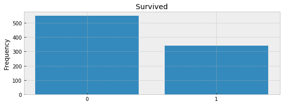

```
Survived:
0    549
1    342
Name: Survived, dtype: int64
```

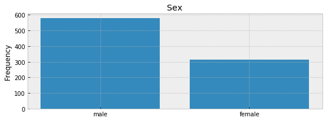

```
Sex:
male      577
female    314
Name: Sex, dtype: int64
```

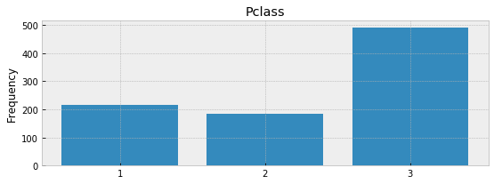

```
Pclass:
3    491
1    216
2    184
Name: Pclass, dtype: int64
```

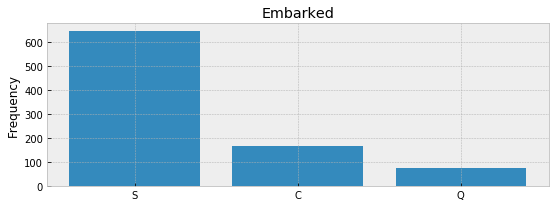

```
Embarked:
S    644
C    168
Q     77
Name: Embarked, dtype: int64
```

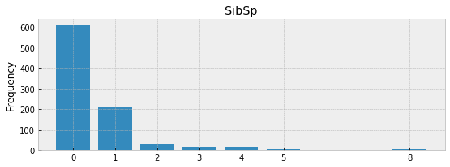

```
SibSp:
0    608
1    209
2     28
4     18
3     16
8      7
5      5
Name: SibSp, dtype: int64
```

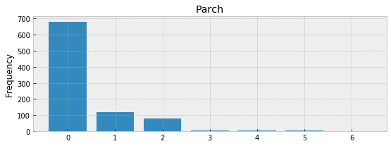

```
Parch:
0    678
1    118
2     80
5      5
3      5
4      4
6      1
Name: Parch, dtype: int64
```

```python
category1=["Survived","Sex","Pclass","Embarked","SibSp", "Parch"]
for i in category1:
    bar_plot(i)
```

### b) Numerical Variable

```python
def plot_hist(variable):
    plt.figure(figsize=(9,3))
    plt.hist(train_df[variable],bins=50)
    plt.xlabel(variable)
    plt.ylabel("Frequency")
    plt.title("{} distribution withhist".format(variable))
    plt.show()
```

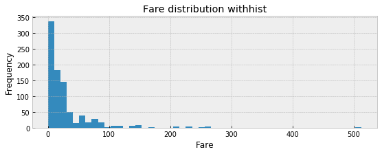

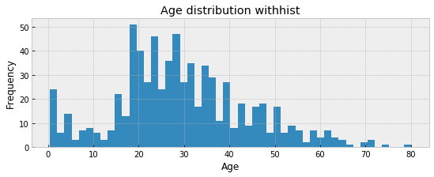

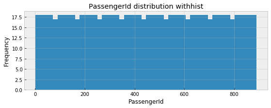

```python
numericVar = ["Fare","Age","PassengerId"]
for i in numericVar:
    plot_hist(i)
```

# 3) Basic Data Analysis

- Pclass - Survived
- Sex - Survived
- SibSp - Survived
- Parch - Survived
- First class and women's - Survived
- Groupby(Pclass and Sex) -- Survived

```python
# Pclass - Survived
train_df[["Pclass","Survived"]].groupby(["Pclass"],as_index=False).mean().sort_values(by="Survived",ascending = False)
```

|  | Pclass | Survived |
| --- | --- | --- |
| 0 | 1 | 0.629630 |
| 1 | 2 | 0.472826 |
| 2 | 3 | 0.242363 |

```python
#Sex - Survived

train_df[["Sex","Survived"]].groupby(["Sex"],as_index=False).mean().sort_values(by="Survived",ascending=False)
```

|  | Sex | Survived |
| --- | --- | --- |
| 0 | female | 0.742038 |
| 1 | male | 0.188908 |

```python
#SibSp - Survived

train_df[["SibSp","Survived"]].groupby(["SibSp"],as_index=False).mean().sort_values(by="Survived",ascending=False)
```

|  | SibSp | Survived |
| --- | --- | --- |
| 1 | 1 | 0.535885 |
| 2 | 2 | 0.464286 |
| 0 | 0 | 0.345395 |
| 3 | 3 | 0.250000 |
| 4 | 4 | 0.166667 |
| 5 | 5 | 0.000000 |
| 6 | 8 | 0.000000 |

```python
#Parch - Survived

train_df[["Parch","Survived"]].groupby(["Parch"],as_index=False).mean().sort_values(by="Survived",ascending=False)
```

|  | Parch | Survived |
| --- | --- | --- |
| 3 | 3 | 0.600000 |
| 1 | 1 | 0.550847 |
| 2 | 2 | 0.500000 |
| 0 | 0 | 0.343658 |
| 5 | 5 | 0.200000 |
| 4 | 4 | 0.000000 |
| 6 | 6 | 0.000000 |

```python
#First class and women's - Survived

df_filtered = train_df.loc[(train_df['Pclass'] == 1) & (train_df['Sex'] == "female")]
df_filtered[["Pclass","Sex","Survived"]].groupby(["Pclass"],as_index=False).mean().sort_values(by="Survived",ascending=False)
```

|  | Pclass | Survived |
| --- | --- | --- |
| 0 | 1 | 0.968085 |

```python
#Groupby(Pclass and Sex) -- Survived
train_df[["Pclass","Sex","Survived"]].groupby(["Sex","Pclass"]).mean().sort_values(by="Survived",ascending=False)
```

| Sex | Pclass | Survived |
| --- | --- | --- |
| female | 1 | 0.968085 |
|  | 2 | 0.921053 |
|  | 3 | 0.500000 |
| male | 1 | 0.368852 |
|  | 2 | 0.157407 |
|  | 3 | 0.135447 |

# 4) Outlier Analysis

- Delete datas that break your dataset
- Quartile analysis(Q1, Q2, Q3)
- TR(Veri kümesini bozan uçuk kaçık verilerin silinmesi)

```python
def detect_outliers(df,features):
    outlier_indices = []

    for c in features:
        # 1st quartile
        Q1 = np.percentile(df[c],25)
        # 3rd quartile
        Q3 = np.percentile(df[c],75)
        # IQR
        IQR =  Q3 - Q1
        # Outlier step
        outlier_step= IQR * 1.5
        # Detect outlier and their indeces
        outlier_list_col = df[(df[c] < Q1 - outlier_step) | (df[c] > Q3 + outlier_step)].index
        # Store indeces
        outlier_indices.extend(outlier_list_col)

    outlier_indices = Counter(outlier_indices)
    multiple_outliers = list(i for i,v in outlier_indices.items() if v >2)

    return multiple_outliers
```

```python
train_df.loc[detect_outliers(train_df,["Age","SibSp","Parch","Fare"])]
```

|  | PassengerId | Survived | Pclass | Name | Sex | Age | SibSp | Parch | Ticket | Fare | Cabin | Embarked |
| --- | --- | --- | --- | --- | --- | --- | --- | --- | --- | --- | --- | --- |
| 27 | 28 | 0 | 1 | Fortune, Mr. Charles Alexander | male | 19.0 | 3 | 2 | 19950 | 263.00 | C23 C25 C27 | S |
| 88 | 89 | 1 | 1 | Fortune, Miss. Mabel Helen | female | 23.0 | 3 | 2 | 19950 | 263.00 | C23 C25 C27 | S |
| 159 | 160 | 0 | 3 | Sage, Master. Thomas Henry | male | NaN | 8 | 2 | CA. 2343 | 69.55 | NaN | S |
| 180 | 181 | 0 | 3 | Sage, Miss. Constance Gladys | female | NaN | 8 | 2 | CA. 2343 | 69.55 | NaN | S |
| 201 | 202 | 0 | 3 | Sage, Mr. Frederick | male | NaN | 8 | 2 | CA. 2343 | 69.55 | NaN | S |
| 324 | 325 | 0 | 3 | Sage, Mr. George John Jr | male | NaN | 8 | 2 | CA. 2343 | 69.55 | NaN | S |
| 341 | 342 | 1 | 1 | Fortune, Miss. Alice Elizabeth | female | 24.0 | 3 | 2 | 19950 | 263.00 | C23 C25 C27 | S |
| 792 | 793 | 0 | 3 | Sage, Miss. Stella Anna | female | NaN | 8 | 2 | CA. 2343 | 69.55 | NaN | S |
| 846 | 847 | 0 | 3 | Sage, Mr. Douglas Bullen | male | NaN | 8 | 2 | CA. 2343 | 69.55 | NaN | S |
| 863 | 864 | 0 | 3 | Sage, Miss. Dorothy Edith "Dolly" | female | NaN | 8 | 2 | CA. 2343 | 69.55 | NaN | S |

```python
# Drop outliers
train_df = train_df.drop(detect_outliers(train_df,["Age","SibSp","Parch","Fare"]),axis = 0).reset_index(drop=True)
```

# 5) Missing Value

- Find Missing Value
- Fill Missing Value

### A) Find Missing Value

```python
train_df_len = len(train_df)
train_df=pd.concat([train_df,test_df],axis= 0).reset_index(drop=True)
```

```python
train_df.columns[train_df.isnull().any()]
```

```
Index(['Age', 'Cabin', 'Embarked', 'Fare', 'Survived'], dtype='object')
```

```python
train_df.isnull().sum()
```

```
Age             256
Cabin          1007
Embarked          2
Fare              1
Name              0
Parch             0
PassengerId       0
Pclass            0
Sex               0
SibSp             0
Survived        418
Ticket            0
dtype: int64
```

### B) Fill Missing Value

```python
train_df[train_df["Embarked"].isnull()]
```

|  | Age | Cabin | Embarked | Fare | Name | Parch | PassengerId | Pclass | Sex | SibSp | Survived | Ticket |
| --- | --- | --- | --- | --- | --- | --- | --- | --- | --- | --- | --- | --- |
| 60 | 38.0 | B28 | NaN | 80.0 | Icard, Miss. Amelie | 0 | 62 | 1 | female | 0 | 1.0 | 113572 |
| 821 | 62.0 | B28 | NaN | 80.0 | Stone, Mrs. George Nelson (Martha Evelyn) | 0 | 830 | 1 | female | 0 | 1.0 | 113572 |

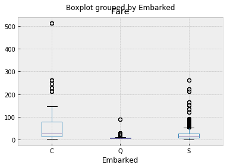

```python
train_df.boxplot(column="Fare",by = "Embarked")
plt.show()
```

```python
train_df["Embarked"] = train_df["Embarked"].fillna("C")
```

```python
train_df[train_df["Embarked"].isnull()]
```

|  | Age | Cabin | Embarked | Fare | Name | Parch | PassengerId | Pclass | Sex | SibSp | Survived | Ticket |
| --- | --- | --- | --- | --- | --- | --- | --- | --- | --- | --- | --- | --- |

```python
train_df[train_df["Fare"].isnull()]
```

|  | Age | Cabin | Embarked | Fare | Name | Parch | PassengerId | Pclass | Sex | SibSp | Survived | Ticket |
| --- | --- | --- | --- | --- | --- | --- | --- | --- | --- | --- | --- | --- |
| 1033 | 60.5 | NaN | S | NaN | Storey, Mr. Thomas | 0 | 1044 | 3 | male | 0 | NaN | 3701 |

```python
# Mean of the Fares according to Pclass 3
meanFP3=np.mean(train_df[train_df["Pclass"] == 3]["Fare"])
```

```python
train_df["Fare"]= train_df["Fare"].fillna(meanFP3)
```

```python
train_df[train_df["Fare"].isnull()]
```

|  | Age | Cabin | Embarked | Fare | Name | Parch | PassengerId | Pclass | Sex | SibSp | Survived | Ticket |
| --- | --- | --- | --- | --- | --- | --- | --- | --- | --- | --- | --- | --- |

# 6) Visualization

### A) Correlation Between Sibsp -- Parch -- Age -- Fare -- Survived

[figure not shown]

```python
list1=["SibSp","Parch","Fare","Age","Survived"]
plt.figure(figsize=(10,5))
sns.heatmap(train_df[list1].corr(),annot=True,fmt=".2f")

plt.show()
```

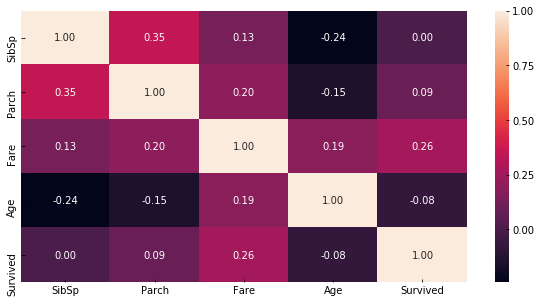

```python
list1=["SibSp","Parch","Fare","Age","Survived"]
plt.figure(figsize=(10,5))
ax=sns.heatmap(train_df[list1].corr(),annot=True,fmt=".2f")
bottom, top = ax.get_ylim()
# these are for making full size/(with ax variable)
ax.set_ylim(bottom + 0.5, top - 0.5)

plt.show()
```

- Fare feature seems to have correlation with survived feature(0.26)

## B) SibSp -- Survived

```
<function matplotlib.pyplot.show(*args, **kw)>
```

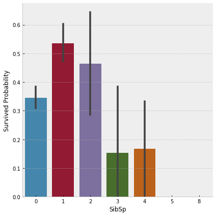

```python
B_SibSp_Survived= sns.factorplot(data=train_df,x="SibSp",y="Survived",kind="bar",size=6)
B_SibSp_Survived.set_ylabels("Survived Probability")
plt.show
```

- If passenger have a lot of SibSp (3,4,5,6....) passenger's survive chance is less
- if SibSp == 0,1,2 passenger have more chance to survive

## C) Parch -- Survived

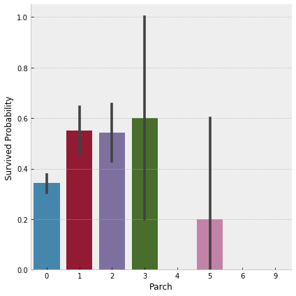

```python
B_Parch_Survived=sns.factorplot(data=train_df,x="Parch",y="Survived",kind="bar",size=6)
B_Parch_Survived.set_ylabels("Survived Probability")
plt.show()
```

- If passenger have 3 or 2 or 1 Parch then passenger have more chance to survive but Parch 3's has std
- If passenger has no Parch or 5 Parch then passenger has lower chance to survive
- Small familes have more chance to survive.

## D) Pclass -- Survived

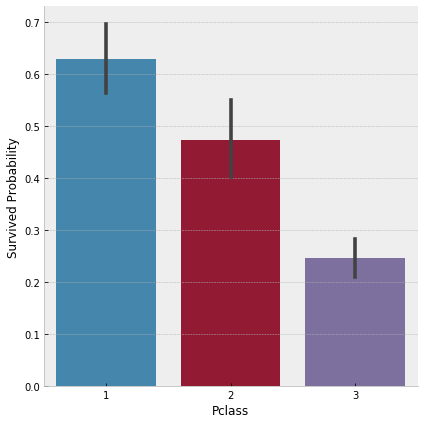

```python
B_Pclass_Survived=sns.factorplot(data=train_df,x="Pclass",y="Survived",kind="bar",size=6)
B_Pclass_Survived.set_ylabels("Survived Probability")
plt.show()
```

- we see that if passenger has first class ticket then passenger has big chance to survive

## E) Age -- Survived

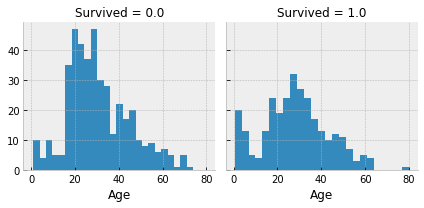

```python
B_Age_Survived=sns.FacetGrid(data=train_df,col="Survived")
B_Age_Survived.map(plt.hist,"Age",bins=25)
plt.show()
```

- The oldest survivor was 80 years old
- Age 10 and 30 has a high survival rate,
- Large number of 20 years old didn't survive

## F) Pclass -- Survived -- Age

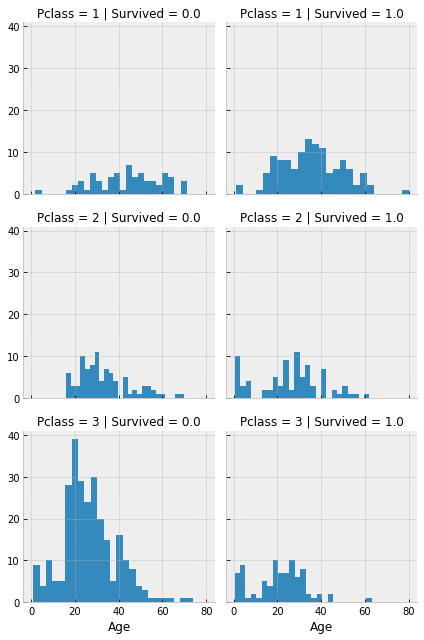

```python
B_Pclass_Age_Survived=sns.FacetGrid(data=train_df,col="Survived",row="Pclass",size=3)
#(From up to down Pclass,From left to right survived)
B_Pclass_Age_Survived.map(plt.hist,"Age",bins=25)
plt.show()
```

- First class has big rate of the chance to survive
- Third class has low rate of the chance to survive
- **Pclass is important feature for model training.

## G) Embarked -- Sex -- Pclass -- Survived

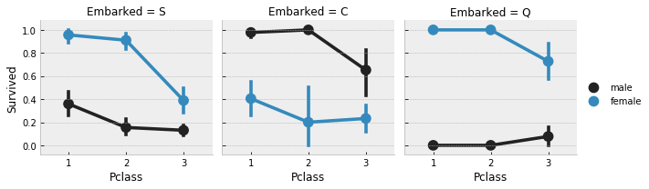

```python
B_Embarked_Sex_Pclass_Survived=sns.FacetGrid(data=train_df,col="Embarked",size=3)
# (From up to down Pclass,From left to right survived)
B_Embarked_Sex_Pclass_Survived.map(sns.pointplot,"Pclass","Survived","Sex")
B_Embarked_Sex_Pclass_Survived.add_legend()
plt.show()
```

## H) Embarked -- Sex -- Fare -- Survived

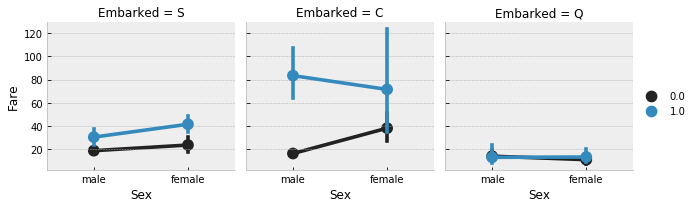

```python
B_Embarked_Sex_Pclass_Survived=sns.FacetGrid(data=train_df,col="Embarked",size=3)
# (From up to down Pclass,From left to right survived)
B_Embarked_Sex_Pclass_Survived.map(sns.pointplot,"Sex","Fare","Survived")
B_Embarked_Sex_Pclass_Survived.add_legend()
plt.show()
```

- In Embarked Q has same ratio of surviving for both gender
- In Embarked C if female pays much then they have big chance to survive
- Passenger who pay higher fare have better survival
- Fare can be used as categorical for training

## I) Fill Missing: Age Feature

```python
train_df[train_df["Age"].isnull()]
```

|  | Age | Cabin | Embarked | Fare | Name | Parch | PassengerId | Pclass | Sex | SibSp | Survived | Ticket |
| --- | --- | --- | --- | --- | --- | --- | --- | --- | --- | --- | --- | --- |
| 5 | NaN | NaN | Q | 8.4583 | Moran, Mr. James | 0 | 6 | 3 | male | 0 | 0.0 | 330877 |
| 17 | NaN | NaN | S | 13.0000 | Williams, Mr. Charles Eugene | 0 | 18 | 2 | male | 0 | 1.0 | 244373 |
| 19 | NaN | NaN | C | 7.2250 | Masselmani, Mrs. Fatima | 0 | 20 | 3 | female | 0 | 1.0 | 2649 |
| 26 | NaN | NaN | C | 7.2250 | Emir, Mr. Farred Chehab | 0 | 27 | 3 | male | 0 | 0.0 | 2631 |
| 27 | NaN | NaN | Q | 7.8792 | O'Dwyer, Miss. Ellen "Nellie" | 0 | 29 | 3 | female | 0 | 1.0 | 330959 |
| ... | ... | ... | ... | ... | ... | ... | ... | ... | ... | ... | ... | ... |
| 1289 | NaN | NaN | Q | 7.7208 | Riordan, Miss. Johanna Hannah"" | 0 | 1300 | 3 | female | 0 | NaN | 334915 |
| 1291 | NaN | NaN | Q | 7.7500 | Naughton, Miss. Hannah | 0 | 1302 | 3 | female | 0 | NaN | 365237 |
| 1294 | NaN | NaN | S | 8.0500 | Spector, Mr. Woolf | 0 | 1305 | 3 | male | 0 | NaN | A.5. 3236 |
| 1297 | NaN | NaN | S | 8.0500 | Ware, Mr. Frederick | 0 | 1308 | 3 | male | 0 | NaN | 359309 |
| 1298 | NaN | NaN | C | 22.3583 | Peter, Master. Michael J | 1 | 1309 | 3 | male | 1 | NaN | 2668 |

256 rows × 12 columns

```python
train_df2=train_df.copy()
train_df2["Sex"]=[1 if i == "female" else 0 for i in train_df2["Sex"]]
```

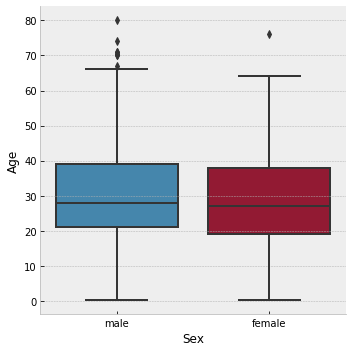

```python
sns.factorplot(x="Sex",y="Age",kind="box",data=train_df)
plt.show()
```

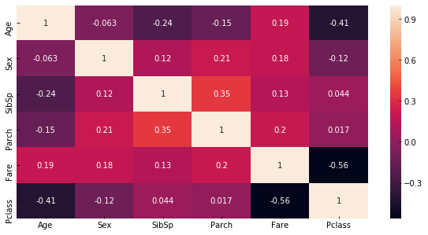

```python
plt.figure(figsize=(10,5))
ax=sns.heatmap(train_df2[["Age","Sex","SibSp","Parch","Fare","Pclass"]].corr(),annot=True)
bottom, top = ax.get_ylim()
ax.set_ylim(bottom + 0.5, top - 0.5)
plt.show()
```

- There is no relation between Sex and Age

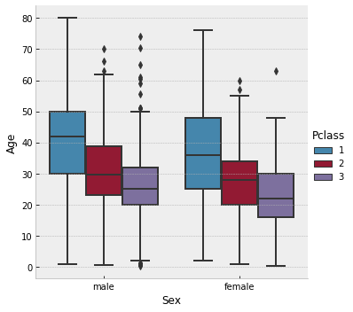

```python
sns.factorplot(x="Sex",y="Age",hue="Pclass",kind="box",data=train_df)
plt.show()
```

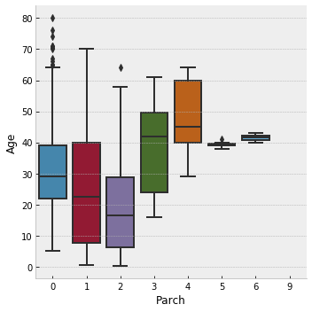

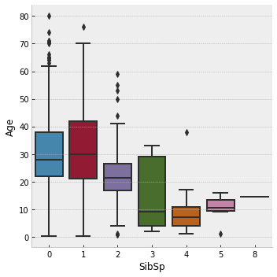

```python
sns.factorplot(x="Parch",y="Age",kind="box",data=train_df)
sns.factorplot(x="SibSp",y="Age",kind="box",data=train_df)
plt.show()
```

```python
index_nan_age = list(train_df["Age"][train_df["Age"].isnull()].index)
for i in index_nan_age:
    age_pred = train_df["Age"][((train_df["SibSp"] == train_df.iloc[i]["SibSp"]) &(train_df["Parch"] == train_df.iloc[i]["Parch"])& (train_df["Pclass"] == train_df.iloc[i]["Pclass"]))].median()
    age_med = train_df["Age"].median()
    if not np.isnan(age_pred):
        train_df["Age"].iloc[i] = age_pred
    #else:
    #    train_df["Age"].iloc[i] = age_med
    #they doesnt work in jupyter that ı commented
train_df["Age"]= train_df["Age"].fillna(age_med)
```

```python
train_df[train_df["Age"].isnull()]
```

|  | Age | Cabin | Embarked | Fare | Name | Parch | PassengerId | Pclass | Sex | SibSp | Survived | Ticket |
| --- | --- | --- | --- | --- | --- | --- | --- | --- | --- | --- | --- | --- |

# 7) Feature Engineering

## A) Name to Title

```python
train_df["Name"].head(10)
```

```
0                              Braund, Mr. Owen Harris
1    Cumings, Mrs. John Bradley (Florence Briggs Th...
2                               Heikkinen, Miss. Laina
3         Futrelle, Mrs. Jacques Heath (Lily May Peel)
4                             Allen, Mr. William Henry
5                                     Moran, Mr. James
6                              McCarthy, Mr. Timothy J
7                       Palsson, Master. Gosta Leonard
8    Johnson, Mrs. Oscar W (Elisabeth Vilhelmina Berg)
9                  Nasser, Mrs. Nicholas (Adele Achem)
Name: Name, dtype: object
```

```python
train_df["Title"]= [ i.split(".")[0].split(",")[-1].strip() for i in train_df["Name"]]
```

```python
train_df.head(5)
```

|  | Age | Cabin | Embarked | Fare | Name | Parch | PassengerId | Pclass | Sex | SibSp | Survived | Ticket | Title |
| --- | --- | --- | --- | --- | --- | --- | --- | --- | --- | --- | --- | --- | --- |
| 0 | 22.0 | NaN | S | 7.2500 | Braund, Mr. Owen Harris | 0 | 1 | 3 | male | 1 | 0.0 | A/5 21171 | Mr |
| 1 | 38.0 | C85 | C | 71.2833 | Cumings, Mrs. John Bradley (Florence Briggs Th... | 0 | 2 | 1 | female | 1 | 1.0 | PC 17599 | Mrs |
| 2 | 26.0 | NaN | S | 7.9250 | Heikkinen, Miss. Laina | 0 | 3 | 3 | female | 0 | 1.0 | STON/O2. 3101282 | Miss |
| 3 | 35.0 | C123 | S | 53.1000 | Futrelle, Mrs. Jacques Heath (Lily May Peel) | 0 | 4 | 1 | female | 1 | 1.0 | 113803 | Mrs |
| 4 | 35.0 | NaN | S | 8.0500 | Allen, Mr. William Henry | 0 | 5 | 3 | male | 0 | 0.0 | 373450 | Mr |

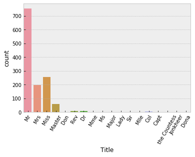

```python
sns.countplot(x="Title", data = train_df) #Counter plot
plt.xticks(rotation = 60)  #Rotation to labels 360
plt.show()
```

```python
train_df["Title"] = train_df["Title"].replace(["Don","Rev","Dr","Mme","Ms","Major","Mlle","Col","Capt","the Countess","Jonkheer","Dona","Sir","Lady"],"Others")
train_df["Title"] = [0 if i=="Mr" else 1 if i=="Mrs" or i=="Miss" else 2  if i =="Master" else 3 for i in train_df["Title"]]
```

- Mr = 0
- Mrs & Miss = 1
- Master = 2
- Others = 3

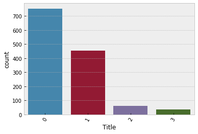

```python
sns.countplot(x="Title", data = train_df) #Counter plot
plt.xticks(rotation = 60)  #Rotation to labels 360
plt.show()
```

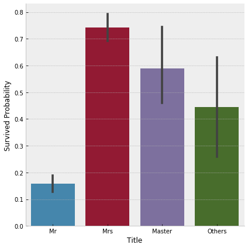

```python
g = sns.factorplot(x="Title",y="Survived",data=train_df,kind="bar",size=6)
g.set_ylabels("Survived Probability")
g.set_xticklabels(["Mr","Mrs","Master","Others"])
plt.show()
```

```python
train_df.drop(labels = ["Name"], axis=1,inplace=True)
```

```python
train_df.head()
```

|  | Age | Cabin | Embarked | Fare | Parch | PassengerId | Pclass | Sex | SibSp | Survived | Ticket | Title |
| --- | --- | --- | --- | --- | --- | --- | --- | --- | --- | --- | --- | --- |
| 0 | 22.0 | NaN | S | 7.2500 | 0 | 1 | 3 | male | 1 | 0.0 | A/5 21171 | 0 |
| 1 | 38.0 | C85 | C | 71.2833 | 0 | 2 | 1 | female | 1 | 1.0 | PC 17599 | 1 |
| 2 | 26.0 | NaN | S | 7.9250 | 0 | 3 | 3 | female | 0 | 1.0 | STON/O2. 3101282 | 1 |
| 3 | 35.0 | C123 | S | 53.1000 | 0 | 4 | 1 | female | 1 | 1.0 | 113803 | 1 |
| 4 | 35.0 | NaN | S | 8.0500 | 0 | 5 | 3 | male | 0 | 0.0 | 373450 | 0 |

```python
train_df=pd.get_dummies(train_df,columns=["Title"])
```

```python
train_df.head()
```

|  | Age | Cabin | Embarked | Fare | Parch | PassengerId | Pclass | Sex | SibSp | Survived | Ticket | Title_0 | Title_1 | Title_2 | Title_3 |
| --- | --- | --- | --- | --- | --- | --- | --- | --- | --- | --- | --- | --- | --- | --- | --- |
| 0 | 22.0 | NaN | S | 7.2500 | 0 | 1 | 3 | male | 1 | 0.0 | A/5 21171 | 1 | 0 | 0 | 0 |
| 1 | 38.0 | C85 | C | 71.2833 | 0 | 2 | 1 | female | 1 | 1.0 | PC 17599 | 0 | 1 | 0 | 0 |
| 2 | 26.0 | NaN | S | 7.9250 | 0 | 3 | 3 | female | 0 | 1.0 | STON/O2. 3101282 | 0 | 1 | 0 | 0 |
| 3 | 35.0 | C123 | S | 53.1000 | 0 | 4 | 1 | female | 1 | 1.0 | 113803 | 0 | 1 | 0 | 0 |
| 4 | 35.0 | NaN | S | 8.0500 | 0 | 5 | 3 | male | 0 | 0.0 | 373450 | 1 | 0 | 0 | 0 |

## B) SipSb,Parch to Family Size

```python
train_df["F_size"]= train_df["SibSp"]+train_df["Parch"]+1
```

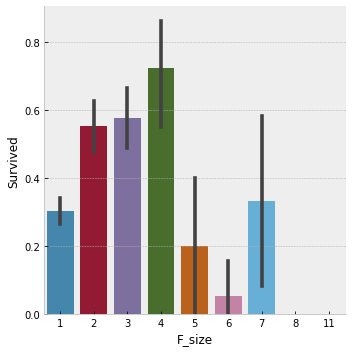

```python
g = sns.factorplot(x="F_size",y="Survived",data=train_df,kind="bar")
plt.show()
```

```python
train_df.head(10)
```

|  | Age | Cabin | Embarked | Fare | Parch | PassengerId | Pclass | Sex | SibSp | Survived | Ticket | Title_0 | Title_1 | Title_2 | Title_3 | F_size |
| --- | --- | --- | --- | --- | --- | --- | --- | --- | --- | --- | --- | --- | --- | --- | --- | --- |
| 0 | 22.0 | NaN | S | 7.2500 | 0 | 1 | 3 | male | 1 | 0.0 | A/5 21171 | 1 | 0 | 0 | 0 | 2 |
| 1 | 38.0 | C85 | C | 71.2833 | 0 | 2 | 1 | female | 1 | 1.0 | PC 17599 | 0 | 1 | 0 | 0 | 2 |
| 2 | 26.0 | NaN | S | 7.9250 | 0 | 3 | 3 | female | 0 | 1.0 | STON/O2. 3101282 | 0 | 1 | 0 | 0 | 1 |
| 3 | 35.0 | C123 | S | 53.1000 | 0 | 4 | 1 | female | 1 | 1.0 | 113803 | 0 | 1 | 0 | 0 | 2 |
| 4 | 35.0 | NaN | S | 8.0500 | 0 | 5 | 3 | male | 0 | 0.0 | 373450 | 1 | 0 | 0 | 0 | 1 |
| 5 | 25.0 | NaN | Q | 8.4583 | 0 | 6 | 3 | male | 0 | 0.0 | 330877 | 1 | 0 | 0 | 0 | 1 |
| 6 | 54.0 | E46 | S | 51.8625 | 0 | 7 | 1 | male | 0 | 0.0 | 17463 | 1 | 0 | 0 | 0 | 1 |
| 7 | 2.0 | NaN | S | 21.0750 | 1 | 8 | 3 | male | 3 | 0.0 | 349909 | 0 | 0 | 1 | 0 | 5 |
| 8 | 27.0 | NaN | S | 11.1333 | 2 | 9 | 3 | female | 0 | 1.0 | 347742 | 0 | 1 | 0 | 0 | 3 |
| 9 | 14.0 | NaN | C | 30.0708 | 0 | 10 | 2 | female | 1 | 1.0 | 237736 | 0 | 1 | 0 | 0 | 2 |

```python
train_df["family_size"] = [ 1 if i <5 else 0 for i in train_df["F_size"]]
```

- Small families is 1 (x < 5)
- Big Families is 0 (x >= 5)

```python
train_df.head(5)
```

|  | Age | Cabin | Embarked | Fare | Parch | PassengerId | Pclass | Sex | SibSp | Survived | Ticket | Title_0 | Title_1 | Title_2 | Title_3 | F_size | family_size |
| --- | --- | --- | --- | --- | --- | --- | --- | --- | --- | --- | --- | --- | --- | --- | --- | --- | --- |
| 0 | 22.0 | NaN | S | 7.2500 | 0 | 1 | 3 | male | 1 | 0.0 | A/5 21171 | 1 | 0 | 0 | 0 | 2 | 1 |
| 1 | 38.0 | C85 | C | 71.2833 | 0 | 2 | 1 | female | 1 | 1.0 | PC 17599 | 0 | 1 | 0 | 0 | 2 | 1 |
| 2 | 26.0 | NaN | S | 7.9250 | 0 | 3 | 3 | female | 0 | 1.0 | STON/O2. 3101282 | 0 | 1 | 0 | 0 | 1 | 1 |
| 3 | 35.0 | C123 | S | 53.1000 | 0 | 4 | 1 | female | 1 | 1.0 | 113803 | 0 | 1 | 0 | 0 | 2 | 1 |
| 4 | 35.0 | NaN | S | 8.0500 | 0 | 5 | 3 | male | 0 | 0.0 | 373450 | 1 | 0 | 0 | 0 | 1 | 1 |

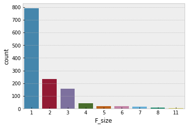

```python
sns.countplot(x="F_size",data=train_df)
plt.show()
```

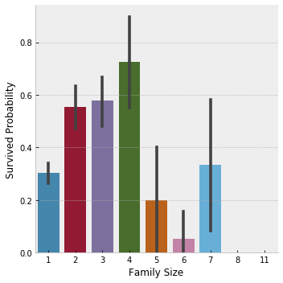

```python
g = sns.factorplot(x="F_size",y="Survived",data=train_df,kind="bar")
g.set_ylabels("Survived Probability")
g.set_xlabels("Family Size")
plt.show()
```

- Small families had more chance to survive than big families.

```python
train_df = pd.get_dummies(train_df,columns=["family_size"])
```

```python
train_df
```

|  | Age | Cabin | Embarked | Fare | Parch | PassengerId | Pclass | Sex | SibSp | Survived | Ticket | Title_0 | Title_1 | Title_2 | Title_3 | F_size | family_size_0 | family_size_1 |
| --- | --- | --- | --- | --- | --- | --- | --- | --- | --- | --- | --- | --- | --- | --- | --- | --- | --- | --- |
| 0 | 22.0 | NaN | S | 7.2500 | 0 | 1 | 3 | male | 1 | 0.0 | A/5 21171 | 1 | 0 | 0 | 0 | 2 | 0 | 1 |
| 1 | 38.0 | C85 | C | 71.2833 | 0 | 2 | 1 | female | 1 | 1.0 | PC 17599 | 0 | 1 | 0 | 0 | 2 | 0 | 1 |
| 2 | 26.0 | NaN | S | 7.9250 | 0 | 3 | 3 | female | 0 | 1.0 | STON/O2. 3101282 | 0 | 1 | 0 | 0 | 1 | 0 | 1 |
| 3 | 35.0 | C123 | S | 53.1000 | 0 | 4 | 1 | female | 1 | 1.0 | 113803 | 0 | 1 | 0 | 0 | 2 | 0 | 1 |
| 4 | 35.0 | NaN | S | 8.0500 | 0 | 5 | 3 | male | 0 | 0.0 | 373450 | 1 | 0 | 0 | 0 | 1 | 0 | 1 |
| ... | ... | ... | ... | ... | ... | ... | ... | ... | ... | ... | ... | ... | ... | ... | ... | ... | ... | ... |
| 1294 | 25.0 | NaN | S | 8.0500 | 0 | 1305 | 3 | male | 0 | NaN | A.5. 3236 | 1 | 0 | 0 | 0 | 1 | 0 | 1 |
| 1295 | 39.0 | C105 | C | 108.9000 | 0 | 1306 | 1 | female | 0 | NaN | PC 17758 | 0 | 0 | 0 | 1 | 1 | 0 | 1 |
| 1296 | 38.5 | NaN | S | 7.2500 | 0 | 1307 | 3 | male | 0 | NaN | SOTON/O.Q. 3101262 | 1 | 0 | 0 | 0 | 1 | 0 | 1 |
| 1297 | 25.0 | NaN | S | 8.0500 | 0 | 1308 | 3 | male | 0 | NaN | 359309 | 1 | 0 | 0 | 0 | 1 | 0 | 1 |
| 1298 | 16.0 | NaN | C | 22.3583 | 1 | 1309 | 3 | male | 1 | NaN | 2668 | 0 | 0 | 1 | 0 | 3 | 0 | 1 |

1299 rows × 18 columns

## C) Embarked

- Getting dummies

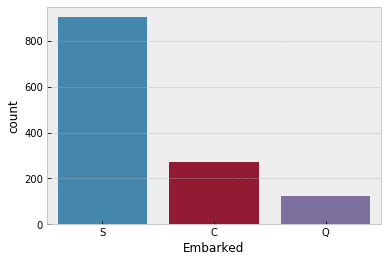

```python
g= sns.countplot(x="Embarked",data=train_df)
plt.show()
```

```python
train_df = pd.get_dummies(train_df,columns=["Embarked"])
```

```python
train_df
```

|  | Age | Cabin | Fare | Parch | PassengerId | Pclass | Sex | SibSp | Survived | Ticket | Title_0 | Title_1 | Title_2 | Title_3 | F_size | family_size_0 | family_size_1 | Embarked_C | Embarked_Q | Embarked_S |
| --- | --- | --- | --- | --- | --- | --- | --- | --- | --- | --- | --- | --- | --- | --- | --- | --- | --- | --- | --- | --- |
| 0 | 22.0 | NaN | 7.2500 | 0 | 1 | 3 | male | 1 | 0.0 | A/5 21171 | 1 | 0 | 0 | 0 | 2 | 0 | 1 | 0 | 0 | 1 |
| 1 | 38.0 | C85 | 71.2833 | 0 | 2 | 1 | female | 1 | 1.0 | PC 17599 | 0 | 1 | 0 | 0 | 2 | 0 | 1 | 1 | 0 | 0 |
| 2 | 26.0 | NaN | 7.9250 | 0 | 3 | 3 | female | 0 | 1.0 | STON/O2. 3101282 | 0 | 1 | 0 | 0 | 1 | 0 | 1 | 0 | 0 | 1 |
| 3 | 35.0 | C123 | 53.1000 | 0 | 4 | 1 | female | 1 | 1.0 | 113803 | 0 | 1 | 0 | 0 | 2 | 0 | 1 | 0 | 0 | 1 |
| 4 | 35.0 | NaN | 8.0500 | 0 | 5 | 3 | male | 0 | 0.0 | 373450 | 1 | 0 | 0 | 0 | 1 | 0 | 1 | 0 | 0 | 1 |
| ... | ... | ... | ... | ... | ... | ... | ... | ... | ... | ... | ... | ... | ... | ... | ... | ... | ... | ... | ... | ... |
| 1294 | 25.0 | NaN | 8.0500 | 0 | 1305 | 3 | male | 0 | NaN | A.5. 3236 | 1 | 0 | 0 | 0 | 1 | 0 | 1 | 0 | 0 | 1 |
| 1295 | 39.0 | C105 | 108.9000 | 0 | 1306 | 1 | female | 0 | NaN | PC 17758 | 0 | 0 | 0 | 1 | 1 | 0 | 1 | 1 | 0 | 0 |
| 1296 | 38.5 | NaN | 7.2500 | 0 | 1307 | 3 | male | 0 | NaN | SOTON/O.Q. 3101262 | 1 | 0 | 0 | 0 | 1 | 0 | 1 | 0 | 0 | 1 |
| 1297 | 25.0 | NaN | 8.0500 | 0 | 1308 | 3 | male | 0 | NaN | 359309 | 1 | 0 | 0 | 0 | 1 | 0 | 1 | 0 | 0 | 1 |
| 1298 | 16.0 | NaN | 22.3583 | 1 | 1309 | 3 | male | 1 | NaN | 2668 | 0 | 0 | 1 | 0 | 3 | 0 | 1 | 1 | 0 | 0 |

1299 rows × 20 columns

## D) Ticket

```python
train_df["Ticket"].head(10)
```

```
0           A/5 21171
1            PC 17599
2    STON/O2. 3101282
3              113803
4              373450
5              330877
6               17463
7              349909
8              347742
9              237736
Name: Ticket, dtype: object
```

```python
train_df["Ticket"]= [i.replace("/","").replace(".","").strip().split()[0] if not i.isdigit() else i.replace(i,"x") for i in train_df["Ticket"]]
```

```python
train_df["Ticket"].head(10)
```

```
0        A5
1        PC
2    STONO2
3         x
4         x
5         x
6         x
7         x
8         x
9         x
Name: Ticket, dtype: object
```

```python
train_df=pd.get_dummies(train_df,columns=["Ticket"],prefix="T")
# Prefix for shortcute name
```

```python
train_df
```

|  | Age | Cabin | Fare | Parch | PassengerId | Pclass | Sex | SibSp | Survived | Title_0 | ... | T_SOTONO2 | T_SOTONOQ | T_SP | T_STONO | T_STONO2 | T_STONOQ | T_SWPP | T_WC | T_WEP | T_x |
| --- | --- | --- | --- | --- | --- | --- | --- | --- | --- | --- | --- | --- | --- | --- | --- | --- | --- | --- | --- | --- | --- |
| 0 | 22.0 | NaN | 7.2500 | 0 | 1 | 3 | male | 1 | 0.0 | 1 | ... | 0 | 0 | 0 | 0 | 0 | 0 | 0 | 0 | 0 | 0 |
| 1 | 38.0 | C85 | 71.2833 | 0 | 2 | 1 | female | 1 | 1.0 | 0 | ... | 0 | 0 | 0 | 0 | 0 | 0 | 0 | 0 | 0 | 0 |
| 2 | 26.0 | NaN | 7.9250 | 0 | 3 | 3 | female | 0 | 1.0 | 0 | ... | 0 | 0 | 0 | 0 | 1 | 0 | 0 | 0 | 0 | 0 |
| 3 | 35.0 | C123 | 53.1000 | 0 | 4 | 1 | female | 1 | 1.0 | 0 | ... | 0 | 0 | 0 | 0 | 0 | 0 | 0 | 0 | 0 | 1 |
| 4 | 35.0 | NaN | 8.0500 | 0 | 5 | 3 | male | 0 | 0.0 | 1 | ... | 0 | 0 | 0 | 0 | 0 | 0 | 0 | 0 | 0 | 1 |
| ... | ... | ... | ... | ... | ... | ... | ... | ... | ... | ... | ... | ... | ... | ... | ... | ... | ... | ... | ... | ... | ... |
| 1294 | 25.0 | NaN | 8.0500 | 0 | 1305 | 3 | male | 0 | NaN | 1 | ... | 0 | 0 | 0 | 0 | 0 | 0 | 0 | 0 | 0 | 0 |
| 1295 | 39.0 | C105 | 108.9000 | 0 | 1306 | 1 | female | 0 | NaN | 0 | ... | 0 | 0 | 0 | 0 | 0 | 0 | 0 | 0 | 0 | 0 |
| 1296 | 38.5 | NaN | 7.2500 | 0 | 1307 | 3 | male | 0 | NaN | 1 | ... | 0 | 1 | 0 | 0 | 0 | 0 | 0 | 0 | 0 | 0 |
| 1297 | 25.0 | NaN | 8.0500 | 0 | 1308 | 3 | male | 0 | NaN | 1 | ... | 0 | 0 | 0 | 0 | 0 | 0 | 0 | 0 | 0 | 1 |
| 1298 | 16.0 | NaN | 22.3583 | 1 | 1309 | 3 | male | 1 | NaN | 0 | ... | 0 | 0 | 0 | 0 | 0 | 0 | 0 | 0 | 0 | 1 |

1299 rows × 56 columns

# E) Pclass

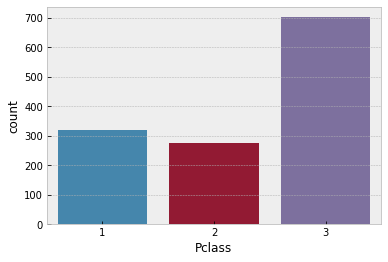

```python
sns.countplot(x="Pclass",data=train_df)
plt.show()
```

```python
train_df["Pclass"] = train_df["Pclass"].astype("category")
train_df = pd.get_dummies(train_df,columns=["Pclass"])
train_df.head()
```

|  | Age | Cabin | Fare | Parch | PassengerId | Sex | SibSp | Survived | Title_0 | Title_1 | ... | T_STONO | T_STONO2 | T_STONOQ | T_SWPP | T_WC | T_WEP | T_x | Pclass_1 | Pclass_2 | Pclass_3 |
| --- | --- | --- | --- | --- | --- | --- | --- | --- | --- | --- | --- | --- | --- | --- | --- | --- | --- | --- | --- | --- | --- |
| 0 | 22.0 | NaN | 7.2500 | 0 | 1 | male | 1 | 0.0 | 1 | 0 | ... | 0 | 0 | 0 | 0 | 0 | 0 | 0 | 0 | 0 | 1 |
| 1 | 38.0 | C85 | 71.2833 | 0 | 2 | female | 1 | 1.0 | 0 | 1 | ... | 0 | 0 | 0 | 0 | 0 | 0 | 0 | 1 | 0 | 0 |
| 2 | 26.0 | NaN | 7.9250 | 0 | 3 | female | 0 | 1.0 | 0 | 1 | ... | 0 | 1 | 0 | 0 | 0 | 0 | 0 | 0 | 0 | 1 |
| 3 | 35.0 | C123 | 53.1000 | 0 | 4 | female | 1 | 1.0 | 0 | 1 | ... | 0 | 0 | 0 | 0 | 0 | 0 | 1 | 1 | 0 | 0 |
| 4 | 35.0 | NaN | 8.0500 | 0 | 5 | male | 0 | 0.0 | 1 | 0 | ... | 0 | 0 | 0 | 0 | 0 | 0 | 1 | 0 | 0 | 1 |

5 rows × 58 columns

## F) Sex

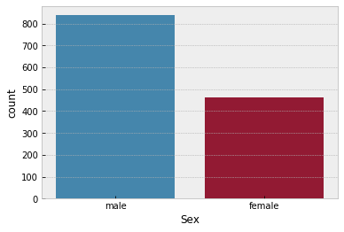

```python
sns.countplot(x="Sex",data=train_df)
plt.show()
```

```python
train_df["Sex"] = train_df["Sex"].astype("category")
train_df = pd.get_dummies(train_df,columns=["Sex"])
train_df.head()
```

|  | Age | Cabin | Fare | Parch | PassengerId | SibSp | Survived | Title_0 | Title_1 | Title_2 | ... | T_STONOQ | T_SWPP | T_WC | T_WEP | T_x | Pclass_1 | Pclass_2 | Pclass_3 | Sex_female | Sex_male |
| --- | --- | --- | --- | --- | --- | --- | --- | --- | --- | --- | --- | --- | --- | --- | --- | --- | --- | --- | --- | --- | --- |
| 0 | 22.0 | NaN | 7.2500 | 0 | 1 | 1 | 0.0 | 1 | 0 | 0 | ... | 0 | 0 | 0 | 0 | 0 | 0 | 0 | 1 | 0 | 1 |
| 1 | 38.0 | C85 | 71.2833 | 0 | 2 | 1 | 1.0 | 0 | 1 | 0 | ... | 0 | 0 | 0 | 0 | 0 | 1 | 0 | 0 | 1 | 0 |
| 2 | 26.0 | NaN | 7.9250 | 0 | 3 | 0 | 1.0 | 0 | 1 | 0 | ... | 0 | 0 | 0 | 0 | 0 | 0 | 0 | 1 | 1 | 0 |
| 3 | 35.0 | C123 | 53.1000 | 0 | 4 | 1 | 1.0 | 0 | 1 | 0 | ... | 0 | 0 | 0 | 0 | 1 | 1 | 0 | 0 | 1 | 0 |
| 4 | 35.0 | NaN | 8.0500 | 0 | 5 | 0 | 0.0 | 1 | 0 | 0 | ... | 0 | 0 | 0 | 0 | 1 | 0 | 0 | 1 | 0 | 1 |

5 rows × 59 columns

## G) Drop Passenger ID and Cabin

```python
train_df.drop(["PassengerId","Cabin"],axis=1,inplace=True)
```

```python
train_df.columns
```

```
Index(['Age', 'Fare', 'Parch', 'SibSp', 'Survived', 'Title_0', 'Title_1',
       'Title_2', 'Title_3', 'F_size', 'family_size_0', 'family_size_1',
       'Embarked_C', 'Embarked_Q', 'Embarked_S', 'T_A', 'T_A4', 'T_A5',
       'T_AQ3', 'T_AQ4', 'T_AS', 'T_C', 'T_CA', 'T_CASOTON', 'T_FC', 'T_FCC',
       'T_Fa', 'T_LINE', 'T_LP', 'T_PC', 'T_PP', 'T_PPP', 'T_SC', 'T_SCA3',
       'T_SCA4', 'T_SCAH', 'T_SCOW', 'T_SCPARIS', 'T_SCParis', 'T_SOC',
       'T_SOP', 'T_SOPP', 'T_SOTONO2', 'T_SOTONOQ', 'T_SP', 'T_STONO',
       'T_STONO2', 'T_STONOQ', 'T_SWPP', 'T_WC', 'T_WEP', 'T_x', 'Pclass_1',
       'Pclass_2', 'Pclass_3', 'Sex_female', 'Sex_male'],
      dtype='object')
```

# Modeling

```python
from sklearn.model_selection import train_test_split, StratifiedKFold, GridSearchCV
from sklearn.linear_model import LogisticRegression
from sklearn.svm import SVC
from sklearn.ensemble import RandomForestClassifier, VotingClassifier
from sklearn.neighbors import KNeighborsClassifier
from sklearn.tree import DecisionTreeClassifier
from sklearn.metrics import accuracy_score
```

## Train - Test Split

```python
train_df_len
```

```
881
```

```python
test = train_df[train_df_len:]
test.drop(labels = ["Survived"],axis = 1, inplace = True)
```

```python
test
```

|  | Age | Fare | Parch | SibSp | Title_0 | Title_1 | Title_2 | Title_3 | F_size | family_size_0 | ... | T_STONOQ | T_SWPP | T_WC | T_WEP | T_x | Pclass_1 | Pclass_2 | Pclass_3 | Sex_female | Sex_male |
| --- | --- | --- | --- | --- | --- | --- | --- | --- | --- | --- | --- | --- | --- | --- | --- | --- | --- | --- | --- | --- | --- |
| 881 | 34.5 | 7.8292 | 0 | 0 | 1 | 0 | 0 | 0 | 1 | 0 | ... | 0 | 0 | 0 | 0 | 1 | 0 | 0 | 1 | 0 | 1 |
| 882 | 47.0 | 7.0000 | 0 | 1 | 0 | 1 | 0 | 0 | 2 | 0 | ... | 0 | 0 | 0 | 0 | 1 | 0 | 0 | 1 | 1 | 0 |
| 883 | 62.0 | 9.6875 | 0 | 0 | 1 | 0 | 0 | 0 | 1 | 0 | ... | 0 | 0 | 0 | 0 | 1 | 0 | 1 | 0 | 0 | 1 |
| 884 | 27.0 | 8.6625 | 0 | 0 | 1 | 0 | 0 | 0 | 1 | 0 | ... | 0 | 0 | 0 | 0 | 1 | 0 | 0 | 1 | 0 | 1 |
| 885 | 22.0 | 12.2875 | 1 | 1 | 0 | 1 | 0 | 0 | 3 | 0 | ... | 0 | 0 | 0 | 0 | 1 | 0 | 0 | 1 | 1 | 0 |
| ... | ... | ... | ... | ... | ... | ... | ... | ... | ... | ... | ... | ... | ... | ... | ... | ... | ... | ... | ... | ... | ... |
| 1294 | 25.0 | 8.0500 | 0 | 0 | 1 | 0 | 0 | 0 | 1 | 0 | ... | 0 | 0 | 0 | 0 | 0 | 0 | 0 | 1 | 0 | 1 |
| 1295 | 39.0 | 108.9000 | 0 | 0 | 0 | 0 | 0 | 1 | 1 | 0 | ... | 0 | 0 | 0 | 0 | 0 | 1 | 0 | 0 | 1 | 0 |
| 1296 | 38.5 | 7.2500 | 0 | 0 | 1 | 0 | 0 | 0 | 1 | 0 | ... | 0 | 0 | 0 | 0 | 0 | 0 | 0 | 1 | 0 | 1 |
| 1297 | 25.0 | 8.0500 | 0 | 0 | 1 | 0 | 0 | 0 | 1 | 0 | ... | 0 | 0 | 0 | 0 | 1 | 0 | 0 | 1 | 0 | 1 |
| 1298 | 16.0 | 22.3583 | 1 | 1 | 0 | 0 | 1 | 0 | 3 | 0 | ... | 0 | 0 | 0 | 0 | 1 | 0 | 0 | 1 | 0 | 1 |

418 rows × 56 columns

```python
x=train_df[:train_df_len]
y=x["Survived"]
x=x.drop(labels="Survived",axis=1)
```

```python
x
```

|  | Age | Fare | Parch | SibSp | Title_0 | Title_1 | Title_2 | Title_3 | F_size | family_size_0 | ... | T_STONOQ | T_SWPP | T_WC | T_WEP | T_x | Pclass_1 | Pclass_2 | Pclass_3 | Sex_female | Sex_male |
| --- | --- | --- | --- | --- | --- | --- | --- | --- | --- | --- | --- | --- | --- | --- | --- | --- | --- | --- | --- | --- | --- |
| 0 | 22.0 | 7.2500 | 0 | 1 | 1 | 0 | 0 | 0 | 2 | 0 | ... | 0 | 0 | 0 | 0 | 0 | 0 | 0 | 1 | 0 | 1 |
| 1 | 38.0 | 71.2833 | 0 | 1 | 0 | 1 | 0 | 0 | 2 | 0 | ... | 0 | 0 | 0 | 0 | 0 | 1 | 0 | 0 | 1 | 0 |
| 2 | 26.0 | 7.9250 | 0 | 0 | 0 | 1 | 0 | 0 | 1 | 0 | ... | 0 | 0 | 0 | 0 | 0 | 0 | 0 | 1 | 1 | 0 |
| 3 | 35.0 | 53.1000 | 0 | 1 | 0 | 1 | 0 | 0 | 2 | 0 | ... | 0 | 0 | 0 | 0 | 1 | 1 | 0 | 0 | 1 | 0 |
| 4 | 35.0 | 8.0500 | 0 | 0 | 1 | 0 | 0 | 0 | 1 | 0 | ... | 0 | 0 | 0 | 0 | 1 | 0 | 0 | 1 | 0 | 1 |
| ... | ... | ... | ... | ... | ... | ... | ... | ... | ... | ... | ... | ... | ... | ... | ... | ... | ... | ... | ... | ... | ... |
| 876 | 27.0 | 13.0000 | 0 | 0 | 0 | 0 | 0 | 1 | 1 | 0 | ... | 0 | 0 | 0 | 0 | 1 | 0 | 1 | 0 | 0 | 1 |
| 877 | 19.0 | 30.0000 | 0 | 0 | 0 | 1 | 0 | 0 | 1 | 0 | ... | 0 | 0 | 0 | 0 | 1 | 1 | 0 | 0 | 1 | 0 |
| 878 | 13.5 | 23.4500 | 2 | 1 | 0 | 1 | 0 | 0 | 4 | 0 | ... | 0 | 0 | 1 | 0 | 0 | 0 | 0 | 1 | 1 | 0 |
| 879 | 26.0 | 30.0000 | 0 | 0 | 1 | 0 | 0 | 0 | 1 | 0 | ... | 0 | 0 | 0 | 0 | 1 | 1 | 0 | 0 | 0 | 1 |
| 880 | 32.0 | 7.7500 | 0 | 0 | 1 | 0 | 0 | 0 | 1 | 0 | ... | 0 | 0 | 0 | 0 | 1 | 0 | 0 | 1 | 0 | 1 |

881 rows × 56 columns

```python
y
```

```
0      0.0
1      1.0
2      1.0
3      1.0
4      0.0
      ...
876    0.0
877    1.0
878    0.0
879    1.0
880    0.0
Name: Survived, Length: 881, dtype: float64
```

```python
x_train,x_test,y_train,y_test=train_test_split(x,y,test_size=0.33,random_state=42)
print("x_train",len(x_train))
print("x_test",len(x_test))
print("y_train",len(y_train))
print("y_test",len(y_test))
```

```
x_train 590
x_test 291
y_train 590
y_test 291
```

## Simple Logistic Regression

```python
log_reg = LogisticRegression()
log_reg.fit(x_train,y_train)
log_reg_score_training = round(log_reg.score(x_train,y_train)*100,2)
log_reg_score_test = round(log_reg.score(x_test,y_test)*100,2)
print("Accuracy of Training : % {}".format(log_reg_score_training))
print("Accuracy of Test : % {}".format(log_reg_score_test))
```

```
Accuracy of Training : % 83.22
Accuracy of Test : % 82.13
```

## Hyperparameter Tuning -- Grid Search -- Cross Validation

- Decision Tree
- SVM
- Random Forest
- KNN
- Logistic Regression

```python
classifiers =[DecisionTreeClassifier(random_state=42),
             SVC(random_state=42),
             RandomForestClassifier(random_state=42),
             LogisticRegression(random_state=42),
             KNeighborsClassifier()]
dt_parameters_dic = {"min_samples_split" : range(10,500,20),
                "max_depth": range(1,20,2)}
svc_parameters_dic = {"kernel" : ["rbf"],
                 "gamma": [0.001, 0.01, 0.1, 1],
                 "C": [1,10,50,100,200,300,1000]}
rf_parameters_dic = {"max_features": [1,3,10],
                "min_samples_split":[2,3,10],
                "min_samples_leaf":[1,3,10],
                "bootstrap":[False],
                "n_estimators":[100,300],
                "criterion":["gini"]}
logreg_parameters_dic = {"C":np.logspace(-3,3,7),
                    "penalty": ["l1","l2"]}
knn_parameters_dic = {"n_neighbors": np.linspace(1,19,10, dtype = int).tolist(),
                 "weights": ["uniform","distance"],
                 "metric":["euclidean","manhattan"]}

classifier_parameters = [dt_parameters_dic,
                         svc_parameters_dic,
                         rf_parameters_dic,
                         logreg_parameters_dic,
                        knn_parameters_dic]
```

```python
ML_Models=["DecisionTreeClassifier", "SVM","RandomForestClassifier",
             "LogisticRegression",
             "KNeighborsClassifier"]
cv_result=[]
best_estimators = []
for i in range(len(classifiers)):
    classifi= GridSearchCV(classifiers[i],param_grid=classifier_parameters[i],cv= StratifiedKFold(n_splits=10),scoring = "accuracy",n_jobs = -1, verbose=1)
    classifi.fit(x_train,y_train)
    cv_result.append(classifi.best_score_)
    best_estimators.append(classifi.best_estimator_)
    print(ML_Models[i]," : ",round(cv_result[i]*100,2))
```

```
Fitting 10 folds for each of 250 candidates, totalling 2500 fits
```

```
[Parallel(n_jobs=-1)]: Using backend LokyBackend with 12 concurrent workers.
[Parallel(n_jobs=-1)]: Done  26 tasks      | elapsed:    2.0s
[Parallel(n_jobs=-1)]: Done 2500 out of 2500 | elapsed:    3.3s finished
[Parallel(n_jobs=-1)]: Using backend LokyBackend with 12 concurrent workers.
```

```
DecisionTreeClassifier  :  82.88
Fitting 10 folds for each of 28 candidates, totalling 280 fits
```

```
[Parallel(n_jobs=-1)]: Done 280 out of 280 | elapsed:    1.1s finished
[Parallel(n_jobs=-1)]: Using backend LokyBackend with 12 concurrent workers.
```

```
SVM  :  79.32
Fitting 10 folds for each of 54 candidates, totalling 540 fits
```

```
[Parallel(n_jobs=-1)]: Done  28 tasks      | elapsed:    0.7s
[Parallel(n_jobs=-1)]: Done 328 tasks      | elapsed:    6.3s
[Parallel(n_jobs=-1)]: Done 540 out of 540 | elapsed:   11.0s finished
```

```
RandomForestClassifier  :  84.58
Fitting 10 folds for each of 14 candidates, totalling 140 fits
```

```
[Parallel(n_jobs=-1)]: Using backend LokyBackend with 12 concurrent workers.
[Parallel(n_jobs=-1)]: Done 140 out of 140 | elapsed:    0.3s finished
[Parallel(n_jobs=-1)]: Using backend LokyBackend with 12 concurrent workers.
```

```
LogisticRegression  :  82.37
Fitting 10 folds for each of 40 candidates, totalling 400 fits
KNeighborsClassifier  :  78.31
```

```
[Parallel(n_jobs=-1)]: Done 400 out of 400 | elapsed:    0.3s finished
```

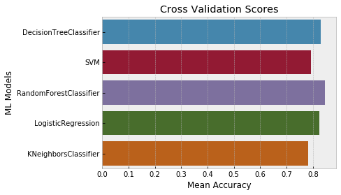

```python
cv_results= pd.DataFrame({"Cross Validation Means":cv_result,"ML Models":["DecisionTreeClassifier", "SVM","RandomForestClassifier",
             "LogisticRegression",
             "KNeighborsClassifier"]})
g= sns.barplot("Cross Validation Means","ML Models",data =cv_results)
g.set_xlabel("Mean Accuracy")
g.set_title("Cross Validation Scores")
```

## Ensemble Modeling

```python
votingC = VotingClassifier(estimators= [("dt",best_estimators[0]),
                                       ("rfc",best_estimators[2]),
                                       ("lr",best_estimators[3])],
                          voting="soft",n_jobs=-1)
votingC=votingC.fit(x_train,y_train)
print(accuracy_score(votingC.predict(x_test),y_test))
```

```
0.8144329896907216
```

## Prediction and Submission

```python
test_survived = pd.Series(votingC.predict(test),name="Survived").astype(int)
results= pd.concat([test_PassengerId,test_survived],axis=1)
results.to_csv("titanic.csv",index=False)
```

```python
newdf= pd.read_csv("titanic.csv")
newdf
```

|  | PassengerId | Survived |
| --- | --- | --- |
| 0 | 892 | 0 |
| 1 | 893 | 1 |
| 2 | 894 | 0 |
| 3 | 895 | 0 |
| 4 | 896 | 1 |
| ... | ... | ... |
| 413 | 1305 | 0 |
| 414 | 1306 | 1 |
| 415 | 1307 | 0 |
| 416 | 1308 | 0 |
| 417 | 1309 | 1 |

418 rows × 2 columns